# IV. Time Series Analysis

## A. Mean Calculation

Calculating the mean of my time series (Total Power Consumption in the Grid)

the formula for the mean is: μ = (x₁ + x₂ + ... + xₙ) / n

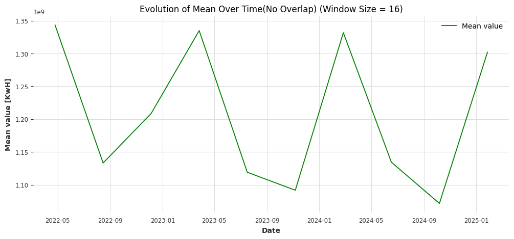

```python
def mean(data):
    return sum(data) / len(data)
def sliced_mean_calculator(data, time_index,variance_window_size):
    means = []
    time_indices = []

    for i in range(0, len(data) - variance_window_size + 1, variance_window_size):
        window_slice = data[i:i + variance_window_size]
        var = mean(window_slice)
        means.append(var)
        time_indices.append(time_index[i + variance_window_size - 1])
    return means, time_indices
mean_window_size = len(energy_consumption_data) // 10
means, time_indices = sliced_mean_calculator(energy_consumption_data,time_index, mean_window_size)
plt.figure(figsize=(12, 5))
plt.plot(time_indices, means, color='green', label='Mean value')
plt.xlabel('Date')
plt.ylabel('Mean value [KwH]')
plt.title(f'Evolution of Mean Over Time(No Overlap) (Window Size = {mean_window_size})')
plt.grid(True)
plt.legend()
plt.show()
```

## B. Variance Calculation

Calculating Variance:

Variance = 1/n sum(xi- mean)**2

```
16
[1.0960480879829592e+16, 1464521258618045.5, 7200982635238046.0, 8155543075894944.0, 2430623248220715.5, 5744999445593979.0, 4415194650633357.5, 3907984911992913.0, 2938256858112266.0, 8608203570732048.0] [Timestamp('2022-04-25 00:00:00'), Timestamp('2022-08-15 00:00:00'), Timestamp('2022-12-05 00:0…
```

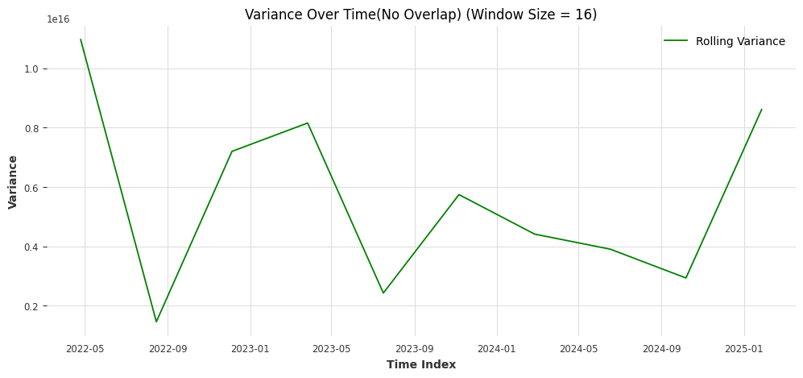

```python
def variance(data):
    mean_value = mean(data)
    variance = sum((x - mean_value)**2 for x in data) / len(data)
    return variance
total_length =  len(energy_consumption_data)
variance_window_size = total_length // 10
print(variance_window_size)
def sliced_variances_calculator(data, time_index,variance_window_size):
    variances = []
    time_indices = []

    for i in range(0, len(data) - variance_window_size + 1, variance_window_size):
        window_slice = data[i:i + variance_window_size]
        var = variance(window_slice)
        variances.append(var)
        time_indices.append(time_index[i + variance_window_size - 1])
    return variances, time_indices

variances, time_indices = sliced_variances_calculator(energy_consumption_data,time_index, variance_window_size)
print(variances, time_indices)
#Plotting the variances
plt.figure(figsize=(12, 5))
plt.plot(time_indices, variances, color='green', label='Rolling Variance')
plt.xlabel('Time Index')
plt.ylabel('Variance')
plt.title(f'Variance Over Time(No Overlap) (Window Size = {variance_window_size})')
plt.grid(True)
plt.legend()
plt.show()
```

## C. Autocorrelation Calculation

```python
from statsmodels.tsa.stattools import acf
import numpy as np
```

autocorrelation function (ACF) at lag k, for k ≥ 0, of the time series is defined by ro k = ck/ c0 where ck is the autocovariance at lag k

```python
alpha = 0.05
confint = 1 - alpha
nlags = 160
def check_autocorrelation(data, nlags=10, alpha=0.05):
    data = np.asarray(data)
    acf_vals, _ = acf(data, nlags=nlags, alpha=alpha)
    return acf_vals

acf_vals = check_autocorrelation(energy_consumption_data, nlags=nlags)
print(f"High Autocorrelation defined as {1 - alpha}")
for lag in range(1, 5):
    print(f"lag {lag:2d} → ACF = {acf_vals[lag]: .4f}")
```

```
High Autocorrelation defined as 0.95
lag  1 → ACF =  0.9028
lag  2 → ACF =  0.8092
lag  3 → ACF =  0.7166
lag  4 → ACF =  0.6537
```

Setting axis at 0

```python
from darts import TimeSeries
```

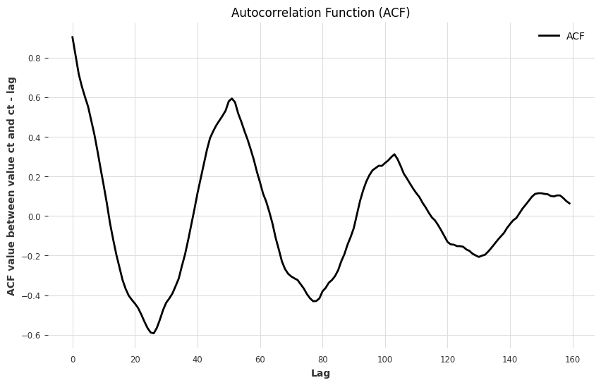

```python
acf_series = TimeSeries.from_values(acf_vals[1:])
plt.figure(figsize=(10, 6))
acf_series.plot(label="ACF")
plt.title("Autocorrelation Function (ACF)")
plt.xlabel("Lag")
plt.ylabel("ACF value between value ct and ct - lag")
plt.legend(loc="upper right")
plt.show()
```

```python
from darts.utils.statistics import (
    plot_acf,
)
```

## D. Differencing

Differencing is a simple approach to removing trends. No need to estimate parameters.

Dt = yt - y(t-1)

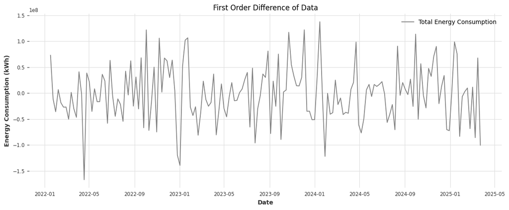

```python
fig, ax = plt.subplots(figsize=(12, 5))
first_order_diff = df['Total Energy Consumption (kWh)'].diff()
ax.plot(first_order_diff, label='Total Energy Consumption', color='gray')
ax.set_title('First Order Diﬀerence of Data')
ax.set_xlabel('Date')
ax.set_ylabel('Energy Consumption (kWh)')
ax.legend()
ax.grid(True)
plt.tight_layout()
plt.show()
```

We can use differencing to remove seasonality, we can then plot its ACF, which will give us more insights for our model selection

```python
from darts.utils.statistics import (
    stationarity_test_kpss,
    plot_acf)
```

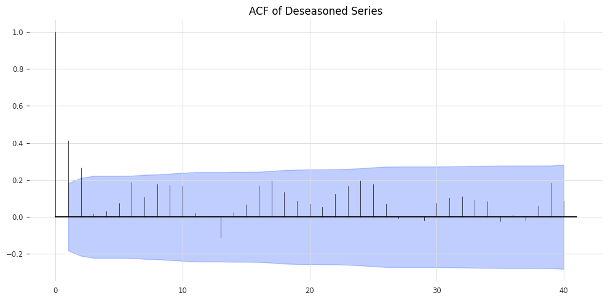

```python
# --- Seasonal differencing (weekly seasonality, lag=52) ---
seasonal_diff = df['Total Energy Consumption (kWh)'].diff(52).dropna()

# --- Convert to Darts TimeSeries ---
seasonal_diff_series = TimeSeries.from_series(seasonal_diff)

# --- Plot ACF using Darts ---
plot_acf(seasonal_diff_series, max_lag=40)
plt.title("ACF of Deseasoned Series")
plt.tight_layout()
plt.show()
```

## E. Testing for stationnarity

```python
from darts.utils.statistics import (
    stationarity_test_kpss,
    stationarity_tests)
```

```python
initial_series = TimeSeries.from_values(energy_consumption_data)
```

```python
alpha=0.05
```

```python
is_stationary = stationarity_test_kpss(initial_series)
stat, p_value, lags, crit_vals = stationarity_test_kpss(initial_series)
print(f"KPSS statistic: {stat}")
print(f"p-value: {p_value}")
is_stationary = alpha <= p_value
print(f"Is stationary: {is_stationary}")
```

```
KPSS statistic: 0.11391747420474804
p-value: 0.1
Is stationary: True
```

```python
is_stationary = stationarity_tests(
    initial_series,
    p_value_threshold_kpss=0.05
)

# Print interpretation
print("Series is stationary" if is_stationary else "Series is not stationary")
```

```
Series is stationary
```

## F. Periodogram and seasonality

There are many methods to test for white noise. One of which, documented in the Time Series Analysis book, is Cumulative Periodogram.

**Periodogram**

```python
def compute_linear_periodogram(y):
    y = np.asarray(y)
    n = len(y)
    m = (n - 1) // 2 if n % 2 else n // 2
    freqs = np.arange(1, m + 1) / n
    I_vals = []

    for omega in freqs:
        cos_part = np.sum(y * np.cos(2 * np.pi * omega * np.arange(1, n + 1)))
        sin_part = np.sum(y * np.sin(2 * np.pi * omega * np.arange(1, n + 1)))
        I = (1 / n) * (cos_part**2 + sin_part**2)
        I_vals.append(I)

    return freqs, np.array(I_vals)
```

```python
valid_mask = time_index.year <= 2024
series_trimmed = energy_consumption_data
series_trimmed = energy_consumption_data[valid_mask]
```

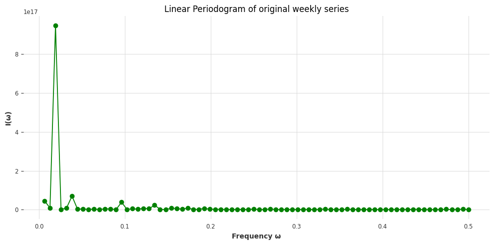

```python
freqs_original, I_vals_original = compute_linear_periodogram(series_trimmed)
plt.figure(figsize=(10, 5))
plt.plot(freqs_original, I_vals_original, marker='o', color = 'g')
plt.title("Linear Periodogram of original weekly series")
plt.xlabel('Frequency ω')
plt.ylabel("I(ω)")
plt.grid(True)
plt.tight_layout()
plt.show()
```

```python
threshold=2*1e16
```

```python
significant_frequencies = [(w, I) for w, I in zip(freqs_original, I_vals_original) if I > threshold]
for freq, power in significant_frequencies:
    print(f"Frequency: {freq:.5f}, Power: {power:.2e}, Period ≈ {1/freq:.2f} weeks")
```

```
Frequency: 0.00641, Power: 4.57e+16, Period ≈ 156.00 weeks
Frequency: 0.01923, Power: 9.48e+17, Period ≈ 52.00 weeks
Frequency: 0.03846, Power: 6.99e+16, Period ≈ 26.00 weeks
Frequency: 0.09615, Power: 3.82e+16, Period ≈ 10.40 weeks
Frequency: 0.13462, Power: 2.34e+16, Period ≈ 7.43 weeks
```

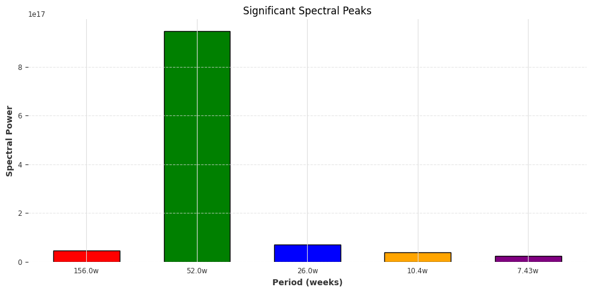

```python
# Extract periods and powers
periods = [round(1 / freq, 2) for freq, _ in significant_frequencies]
powers = [power for _, power in significant_frequencies]

# Define colors for each bar
colors = ['red', 'green', 'blue', 'orange', 'purple']

# Create the bar plot
plt.figure(figsize=(10, 5))
bars = plt.bar(range(len(periods)), powers, color=colors, edgecolor='black', width=0.6)

# Add period labels on x-axis
plt.xticks(range(len(periods)), [f"{p}w" for p in periods])

# Labeling
plt.xlabel("Period (weeks)")
plt.ylabel("Spectral Power")
plt.title("Significant Spectral Peaks")
plt.grid(axis='y', linestyle='--', alpha=0.7)

plt.tight_layout()
plt.show()
```

```python
threshold=2*1e16
significant_frequencies = [(w, I) for w, I in zip(freqs_original, I_vals_original) if I > threshold]
for freq, power in significant_frequencies:
    print(f"Frequency: {freq:.5f}, Power: {power:.2e}, Period ≈ {1/freq:.2f} weeks")
```

```
Frequency: 0.00641, Power: 4.57e+16, Period ≈ 156.00 weeks
Frequency: 0.01923, Power: 9.48e+17, Period ≈ 52.00 weeks
Frequency: 0.03846, Power: 6.99e+16, Period ≈ 26.00 weeks
Frequency: 0.09615, Power: 3.82e+16, Period ≈ 10.40 weeks
Frequency: 0.13462, Power: 2.34e+16, Period ≈ 7.43 weeks
```

Plotting one of the Fourrier Series

```python
from matplotlib.cm import get_cmap
```

Plotting sine waves in separate subplots with different colors.

[figure not shown]

```python
def plot_significant_waves(significant_freqs, duration=30, sampling_rate=100):
    t = np.linspace(0, duration, duration * sampling_rate)
    n = len(significant_freqs)
    cmap = get_cmap('tab10')

    max_amplitude = max(power for _, power in significant_freqs)

    fig, axs = plt.subplots(n, 1, figsize=(11, 1.5 * n), sharex=True)
    if n == 1:
        axs = [axs]

    for i, (freq, power) in enumerate(significant_freqs):
        amplitude = power
        y = amplitude * np.sin(2 * np.pi * freq * t)
        color = cmap(i % cmap.N)
        axs[i].plot(t, y, color=color)
        axs[i].set_ylim(-max_amplitude * 1.1, max_amplitude * 1.1)
        axs[i].set_title(f'ω = {freq:.3f}, T ≈ {1/freq:.2f} days, Power = {power:.2e}', fontsize=10)
        axs[i].set_ylabel('Amplitude (kWh)')
        axs[i].grid(True)

    axs[-1].set_xlabel('Time (weeks)')
    plt.tight_layout()
    fig.suptitle("Decomposed High Signals of Differenced Daily Series (threshold= 2.7*1e16) ", fontsize=14, y=1.02)
    plt.show()

threshold= 0.7*1e16
plot_significant_waves(significant_frequencies, duration=200, sampling_rate=300)
```

We conclude that our Time Series has a 52 week seasonality.

## G. Testing for White Noise

```python
def plot_cumulative_periodogram(freqs, I_vals, show_plot=True, threshold=0.1):
    freqs = np.array(freqs)
    I_vals = np.array(I_vals)

    # Sort by frequency
    sorted_idx = np.argsort(freqs)
    freqs = freqs[sorted_idx]
    I_vals = I_vals[sorted_idx]

    # Keep only non-negative frequencies
    mask = freqs >= 0
    freqs = freqs[mask]
    I_vals = I_vals[mask]

    # Normalize and compute cumulative
    total_power = np.sum(I_vals)
    cumulative_power = np.cumsum(I_vals)
    C = cumulative_power / total_power

    # Expected under white noise: linear
    expected = np.linspace(0, 1, len(C))
    max_deviation = np.max(np.abs(C - expected))
    percent_error = max_deviation * 100
    is_white_noise = percent_error <= threshold * 100

    if show_plot:
        plt.figure(figsize=(10, 5))
        plt.step(freqs, C, where='post', label="Cumulative Periodogram", color='blue', lw=2)
        plt.plot([freqs[0], freqs[-1]], [0, 1], 'r--', label="KS Line: $y = x$")
        plt.xlabel("Frequency ω (1/week)")
        plt.ylabel("Cumulative Proportion of Power")
        plt.title("Cumulative Periodogram vs Flat Spectrum")
        plt.grid(True, linestyle='--', alpha=0.6)
        plt.ylim(0, 1.05)
        plt.legend()
        plt.tight_layout()
        plt.show()

        print(f"Maximum deviation from uniform: {percent_error:.2f}%")
        print("Conclusion:", "Likely white noise" if is_white_noise else "Not white noise")

    return freqs, C
```

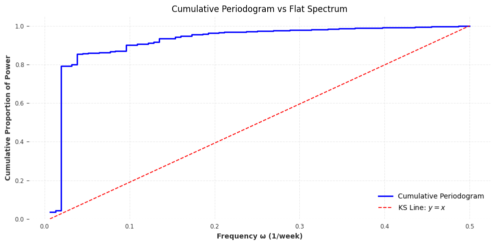

```
Maximum deviation from uniform: 78.97%
Conclusion: Not white noise
```

```python
freqs_sorted, C_vals = plot_cumulative_periodogram(freqs_original, I_vals_original)
```

We conclude that our initial time series is not white noise.